# §1.4 — Features of the Lunar Surface

Unit 1: Intro to the Cosmos · Astronomy

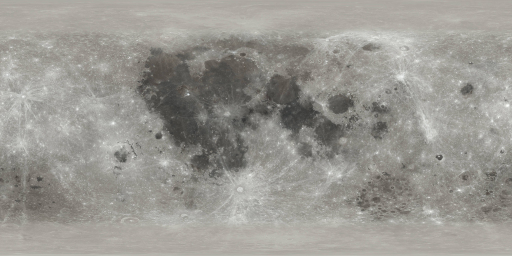

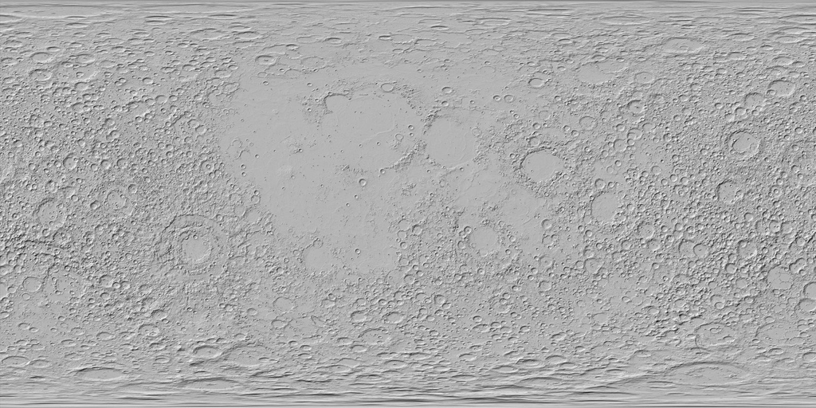

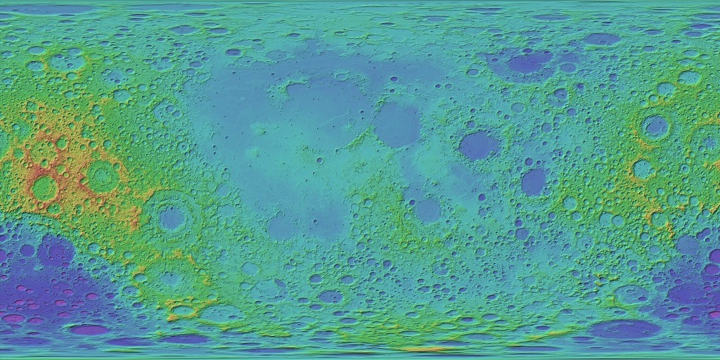

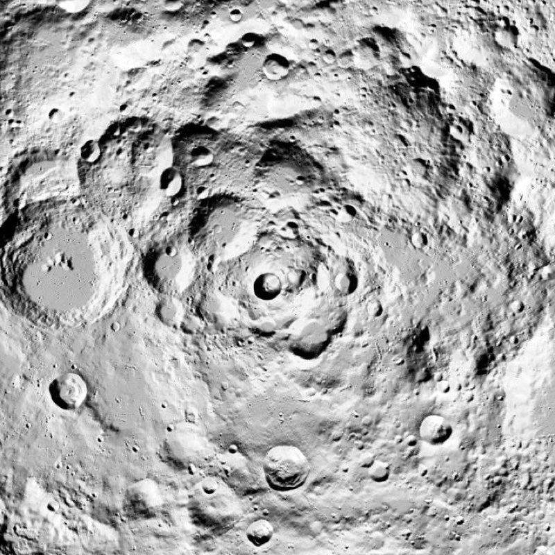

[interactive chart not shown]

Look at a full Moon and two kinds of ground jump out: bright, rough country, and dark, smooth patches. Galileo called the dark patches *maria*, seas. They hold no water, and the far side, which nobody saw until a Soviet probe flew round it in 1959, has almost none of them at all.

Today: what each feature on the Moon's face is, and how it got there.

## 1 · The Moon at a glance

📏

384,400 km

Distance

on average · about 30 Earths side by side · light takes 1.3 s

🌕

3,474 km

Diameter

a little over a quarter of Earth's · about the width of Australia

🪶

1.62 m/s²

Gravity

one sixth of Earth's · a 60 kg person weighs what 10 kg does here

☀️

29.5 days

One lunar day

sunrise to sunrise · two weeks of daylight, then two weeks of night

🌡️

+120 °C → −130 °C

Temperature

day to night at the equator · below −230 °C in polar shadows

💨

No air

Atmosphere

a trillion-fold thinner than ours · no wind, no weather, no sound, no erosion

Earth and Moon to scale

[interactive chart not shown]

speed×1×1 is real time

## 2 · Surface features

Click a tile.

[figure not shown]

1

Maria & highlands

dark seas, bright lands, and a lopsided Moon

[figure not shown]

2

Impact craters

bowls, terraces, central peaks, rays

[figure not shown]

3

Rilles

lava channels and dropped blocks

[figure not shown]

4

Lobate scarps

a shrinking Moon's wrinkles

[figure not shown]

5

Regolith

what the "soil" is

[figure not shown]

6

The poles

eternal shadow, eternal light, and where we'll live

← scroll the tiles →

### Maria and highlands

**Maria** (singular *mare*, Latin for sea) are the dark patches: smooth, low plains of **basalt**, a dense, iron-rich lava that welled up and flooded the biggest impact basins between about 3.9 and 3.1 billion years ago. They cover about 31% of the near side and 2% of the far side.

The **highlands** are the bright ground: rugged, packed with craters, and made of **anorthosite**, a light rock that floated to the top of the young Moon's magma ocean 4.4 billion years ago. The more craters a surface carries, the older it is, so the highlands are the oldest ground on the Moon and the maria the youngest.

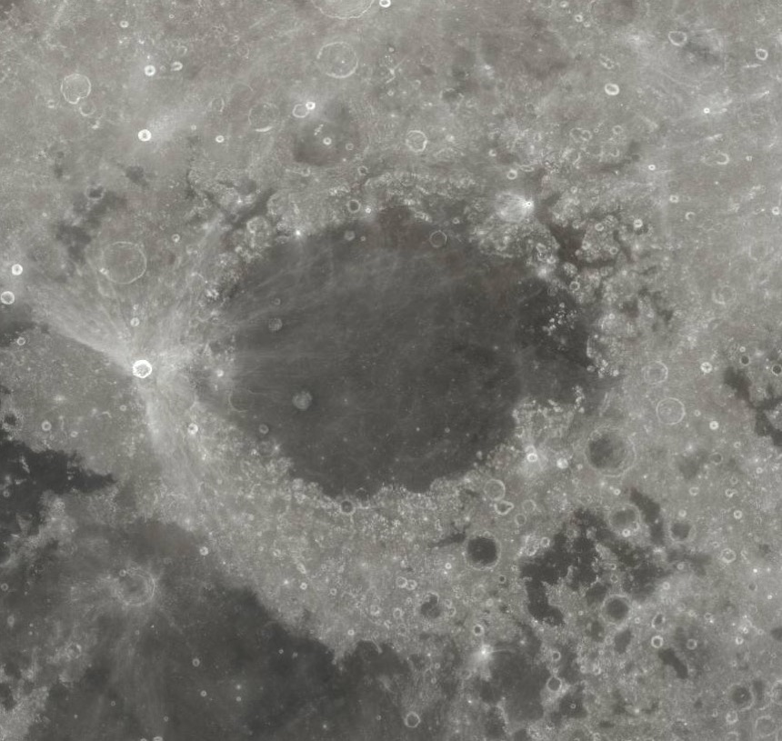

**Mare Crisium**, 560 km across: a dark basalt floor ringed by bright, cratered highlands. NASA LRO WAC mosaic

Two faces — drag the Moon

[interactive chart not shown]

View

Layer

The same face always points at Earth: the Moon spins once for every orbit. The far side was first photographed by Luna 3 in 1959.

Why so lopsided? The far side sits higher and its crust is roughly twice as thick, so lava rarely made it to the surface there. One idea for how it got that way: the Moon once had a companion.

The splat hypothesis

[interactive chart not shown]

timespeed×0.5

Proposed by Jutzi and Asphaug (2011). A rival idea: the near side, facing a still-glowing young Earth, stayed hotter and grew a thinner crust. Either way, thin crust on the near side is why the lava got out there.

How the maria formed — scrub 4.5 billion years

The near side, with today's maria masked until they flood

[interactive chart not shown]

Cross-section through one basin

[interactive chart not shown]

4.5 Gyatoday 4.50 billion years ago speed×0.5

Basin and lava ages are rounded from crater counts and Apollo samples. Oceanus Procellarum kept erupting longest: its youngest flows are about 1.2 billion years old.

### Impact craters

Nearly every hole on the Moon is an **impact crater**. An asteroid or comet arriving at 15–20 km/s vaporises itself and blasts out a bowl ten to twenty times its own size. Craters under about 15 km stay **simple bowls**. Bigger ones collapse under their own weight: the walls slump into **terraces**, the floor flattens, and the centre springs back up into a **central peak**. The largest, over 300 km, become multi-ring **basins**, and the biggest of those are what the maria later filled.

Fresh craters have bright **rays**, streaks of pulverised rock thrown hundreds of kilometres. Rays darken with time, so a rayed crater is young: Tycho is about 110 million years old, Copernicus about 800 million.

Anatomy of an impact

[interactive chart not shown]

timespeed×0.5

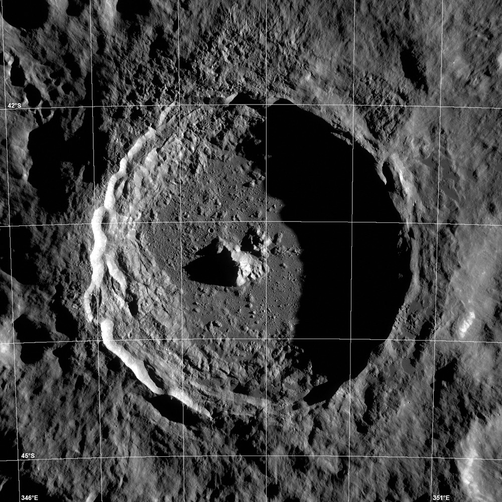

**Tycho**, 85 km: terraced walls, a flat floor and a central peak 2 km high. NASA/GSFC/Arizona State University (LROC)

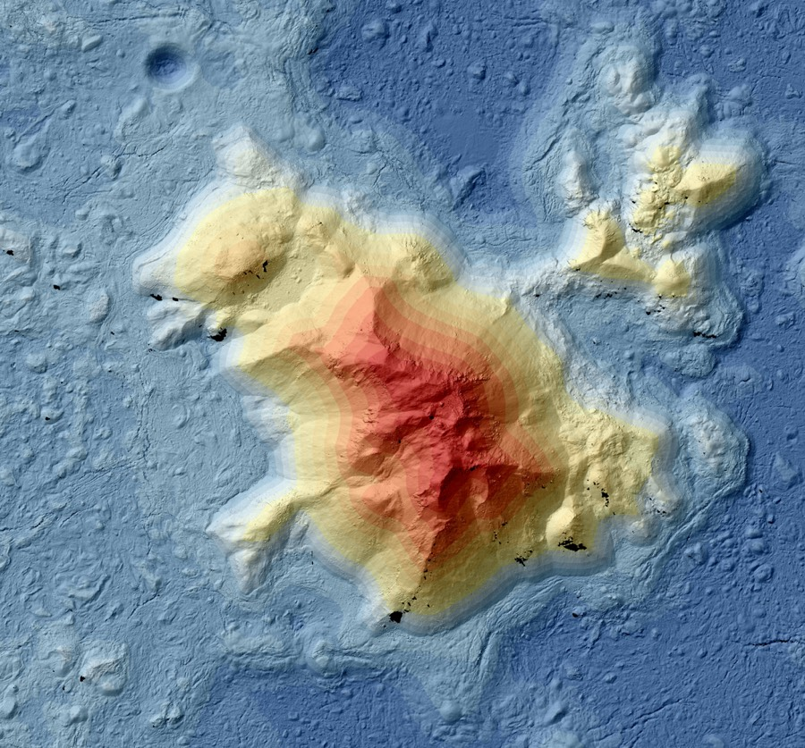

**Tycho's central peak** as an elevation map (red = highest, about 2 km above the floor): rock lifted from kilometres down when the floor rebounded. NASA/GSFC/ASU (LROC)

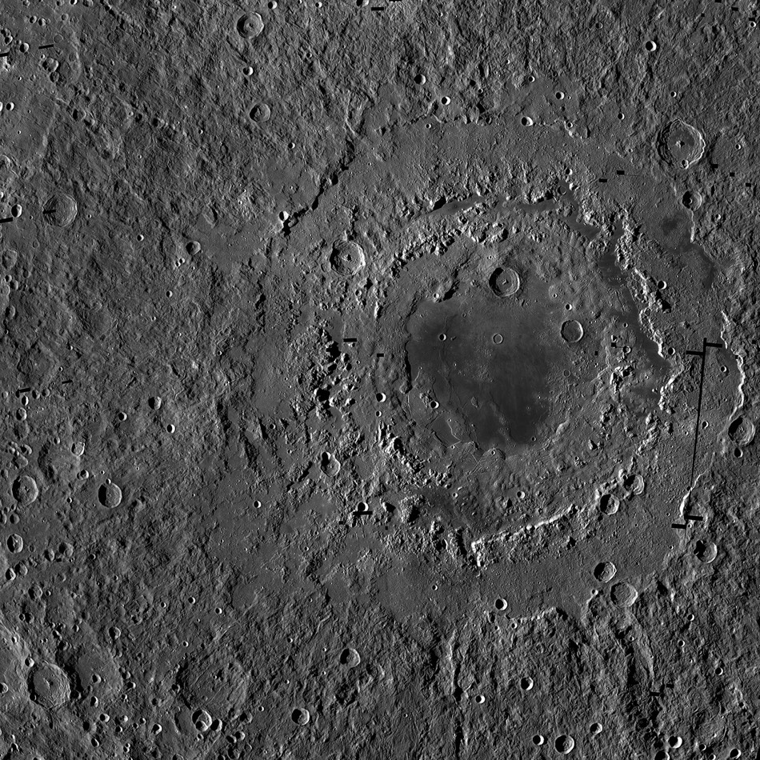

**Orientale**, 930 km: the youngest big basin (3.8 billion years), three rings, only a little lava in the middle. NASA/GSFC/ASU (LROC WAC)

### Rilles

A **rille** (Latin *rima*, a groove) is a long, narrow trench, and there are two kinds. **Sinuous rilles** wind like rivers. They are channels cut by fast-running lava, or lava tubes whose roofs fell in after the lava drained away. Rima Hadley is 1.5 km wide, 300 m deep and 80 km long, and Apollo 15 landed on its bank. **Straight and arcuate rilles** are **graben**: the crust was stretched, split along two parallel faults, and the strip between them dropped. Rima Ariadaeus is 300 km of that.

On the Moonmap (Explore mode) look up Rima Hadley, Rima Ariadaeus, Rima Hyginus, Vallis Schröteri and Rimae Sirsalis.

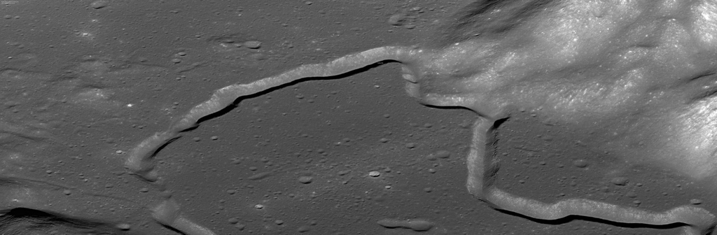

**Rima Hadley** snaking along the foot of the Apennine mountains, seen sideways from orbit. Apollo 15 landed on the plain just right of the bend. NASA/GSFC/ASU (LROC NAC)

Two ways to make a rille

Sinuous: a lava tube collapses

[interactive chart not shown]

Straight: the crust stretches and a block drops

[interactive chart not shown]

timespeed×0.5

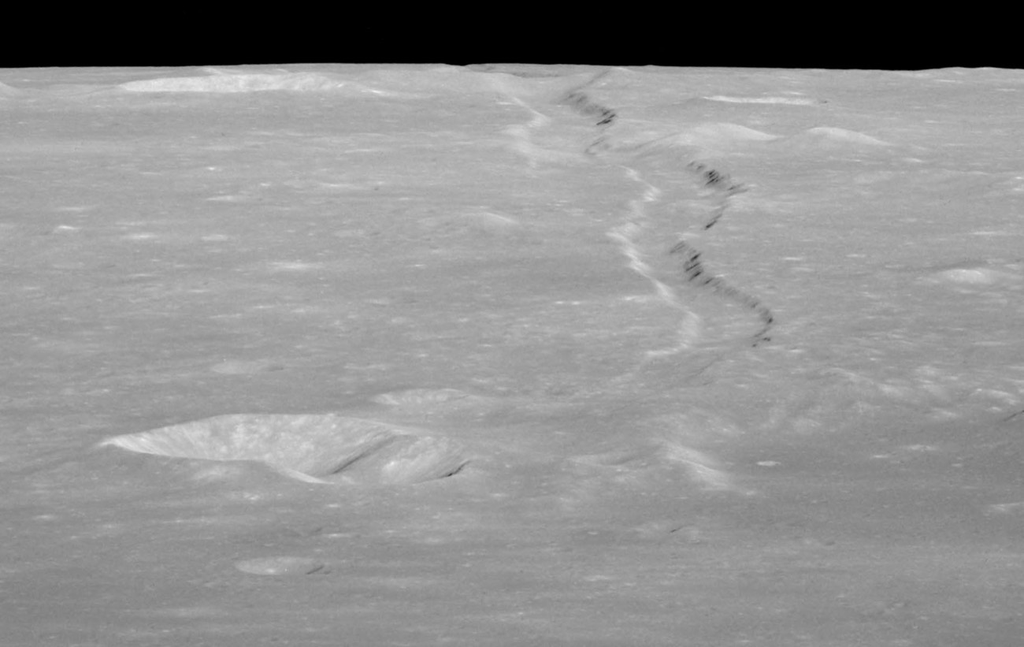

**Rima Ariadaeus**, a straight rille: a dropped block 5 km wide, photographed by Apollo 10. NASA (Apollo 10, AS10-30-4450)

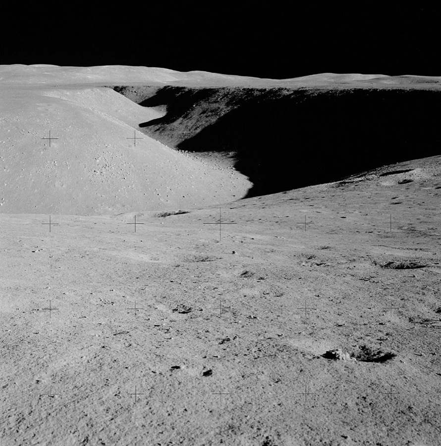

**Standing on the bank:** Rima Hadley from the Apollo 15 site. The far wall is over a kilometre away. NASA (Apollo 15)

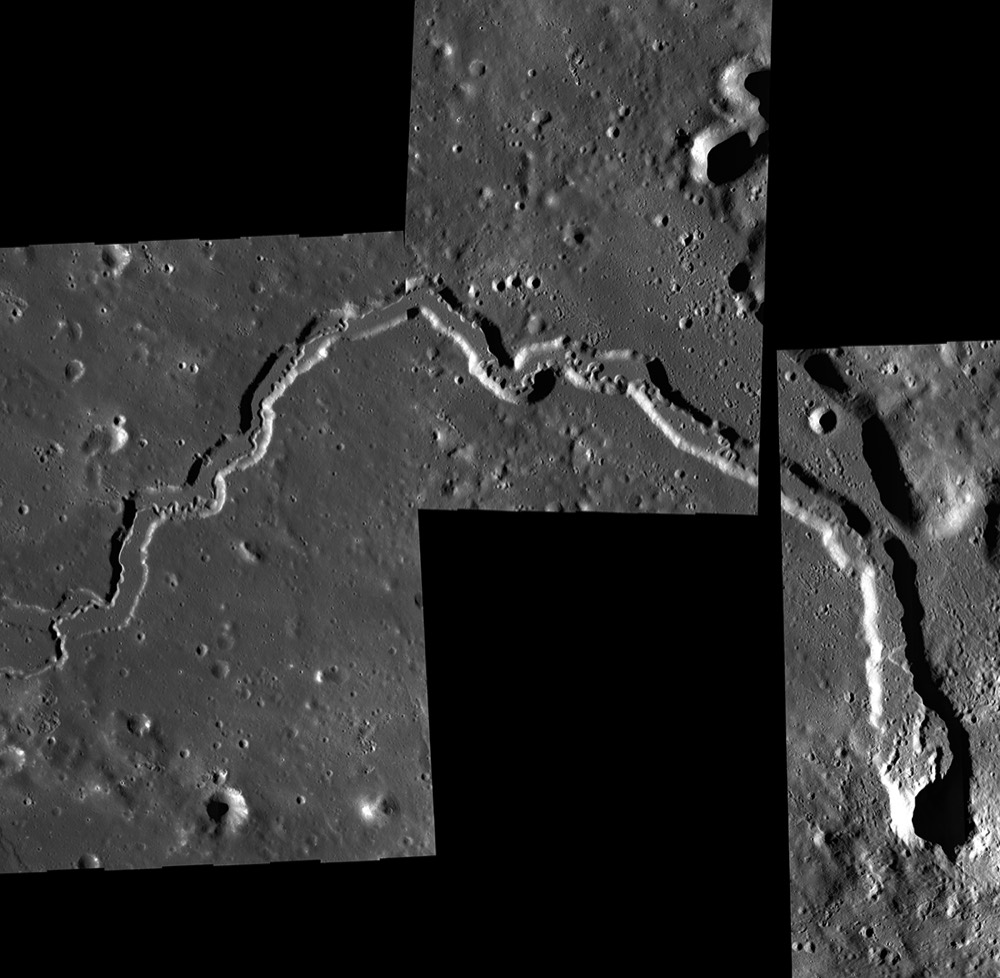

**Vallis Schröteri**, the biggest sinuous rille: 160 km long, up to 10 km wide, starting at a volcanic vent called the Cobra Head. NASA/GSFC/ASU (LROC)

### Lobate scarps

A **lobate scarp** is a low cliff, tens of metres high and a few kilometres long, with a rounded, lobed front. Scarps are **thrust faults**: as the Moon's interior cooled and contracted, the crust was squeezed until it broke and one side rode up over the other. Add up every scarp the Lunar Reconnaissance Orbiter has found, more than 3,500, and the Moon has shrunk by about 50 m in radius over the last few hundred million years.

They are the youngest landforms on the Moon. They cut across small craters, and hardly any craters sit on top of them, so most are under 50 million years old, and some are still moving: the Apollo seismometers recorded shallow moonquakes near several. The Lee-Lincoln scarp crosses the Apollo 17 landing valley, and the astronauts drove their rover up it.

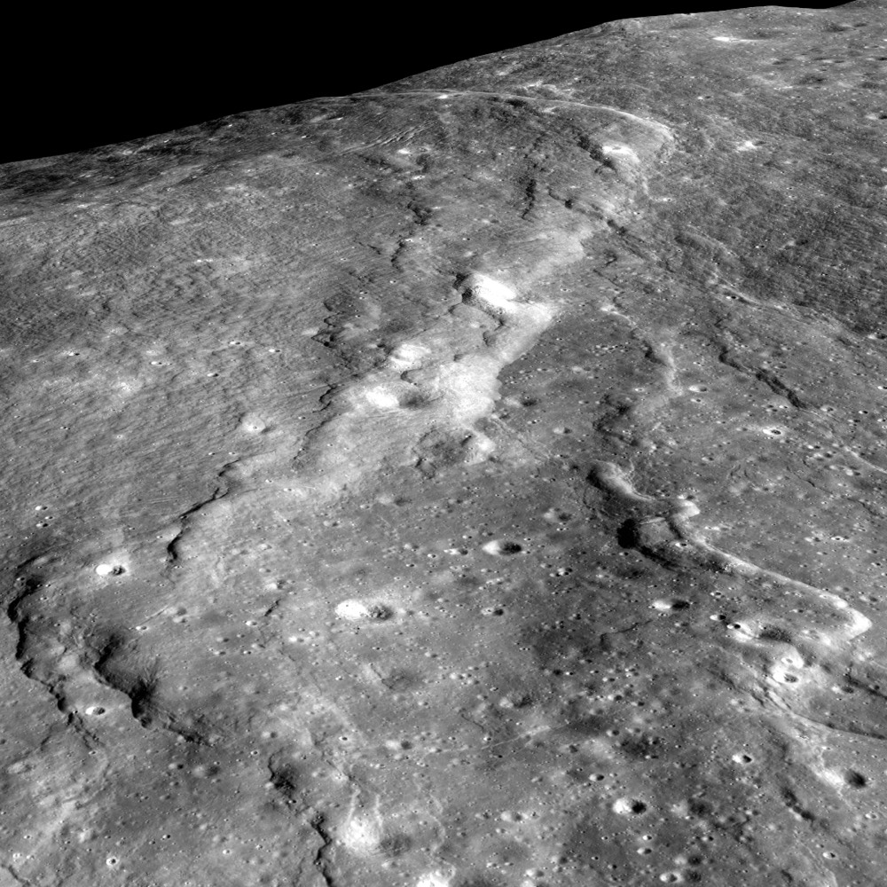

**A lobate scarp** from orbit: the crust on the left has been pushed up and over the ground on the right, leaving a scalloped cliff. NASA/GSFC/Arizona State University (LROC NAC)

A shrinking Moon makes a thrust fault

[interactive chart not shown]

coolingspeed×0.5

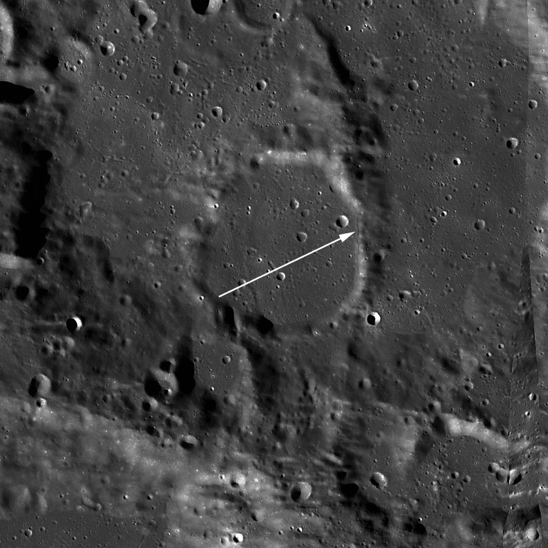

**From straight above** a scarp is just a bright, lobed line (arrow). The crater it runs through is older than the scarp. NASA/GSFC/ASU (LROC NAC)

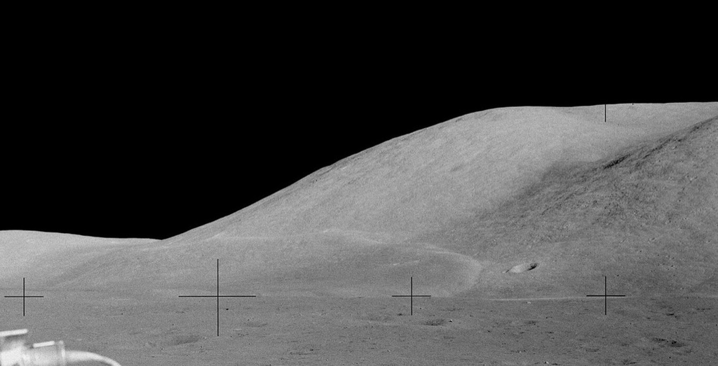

**From the ground** the Lee-Lincoln scarp is a smooth rise about 80 m high; Apollo 17's rover drove up it. NASA (Apollo 17, AS17-135-20649)

### Regolith

There is no soil on the Moon in the Earth sense: no water, no life, nothing rotting. What covers everything is **regolith** (Greek for "blanket of rock"), a layer of loose, broken rock ground up by four billion years of impacts: 2–8 m deep on the maria, 10–15 m on the older highlands. It is jagged rock fragments, tiny glass beads, and **agglutinates** (grains welded together by splashes of impact glass), in every size from boulders down to dust finer than flour.

With no wind or water to wear them smooth, the grains stay razor-edged: they scratch visors, jam zips and joints, and cling to everything with static charge. Apollo astronauts said the dust smelled like spent gunpowder. The only erosion is the slow rain of micrometeorites, so a bootprint lasts millions of years.

[figure not shown]

**Buzz Aldrin's bootprint**, Apollo 11: fine, cohesive regolith holds a crisp print. NASA (AS11-40-5878)

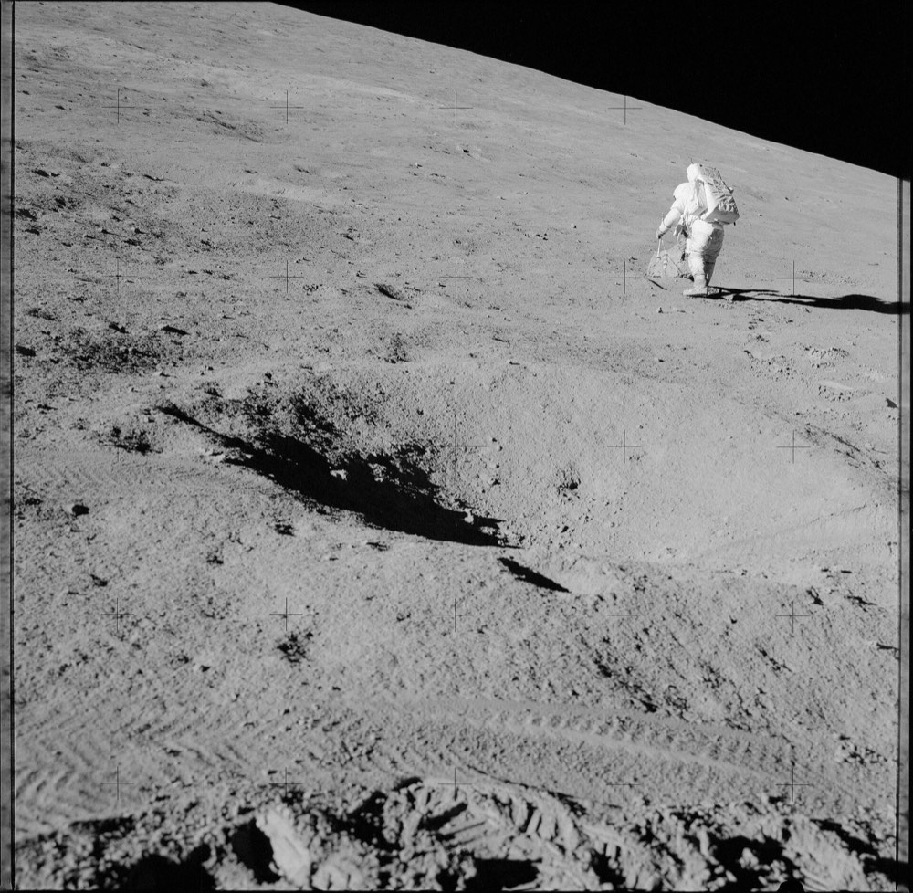

**Apollo 15:** rover tracks, a small fresh crater, and an astronaut walking on a surface that is rock powder all the way down for several metres. NASA (AS15-85-11435)

Four billion years of grinding

[interactive chart not shown]

time speed×0.5

Impacts of every size churn the top layer ("gardening"), so the regolith deepens quickly at first and then slowly: doubling the time does not double the depth.

### The lunar poles

The Moon's axis tilts only 1.5° (Earth's tilts 23.5°), so at the poles the Sun never climbs more than about 1.5° above the horizon: it circles the sky at ground level. The floors of polar craters never see it at all. These **permanently shadowed regions** are among the coldest places in the solar system, below −230 °C, and they trap **water ice** delivered over the ages by comets. NASA's LCROSS probe proved it in 2009 by crashing into Cabeus crater and flying through the splash.

A few crater rims and ridges next door are the opposite: in sunlight more than 80% of the year. Near-constant solar power, ice within driving distance, and temperatures that never swing through the two-week night are why NASA's Artemis landings, and the first bases, are aimed at the south pole. The candidate sites ring Shackleton, de Gerlache, Malapert, Nobile and Haworth.

Why a polar crater never sees the Sun

[interactive chart not shown]

hour speed×0.5

latitude89.5° S crater depth4.2 km

South pole: the candidate landing regions

[interactive chart not shown]

LOLA laser-altimeter relief of the inner 7° around the pole (about 210 km across). Green triangles: NASA's Artemis III candidate landing regions.

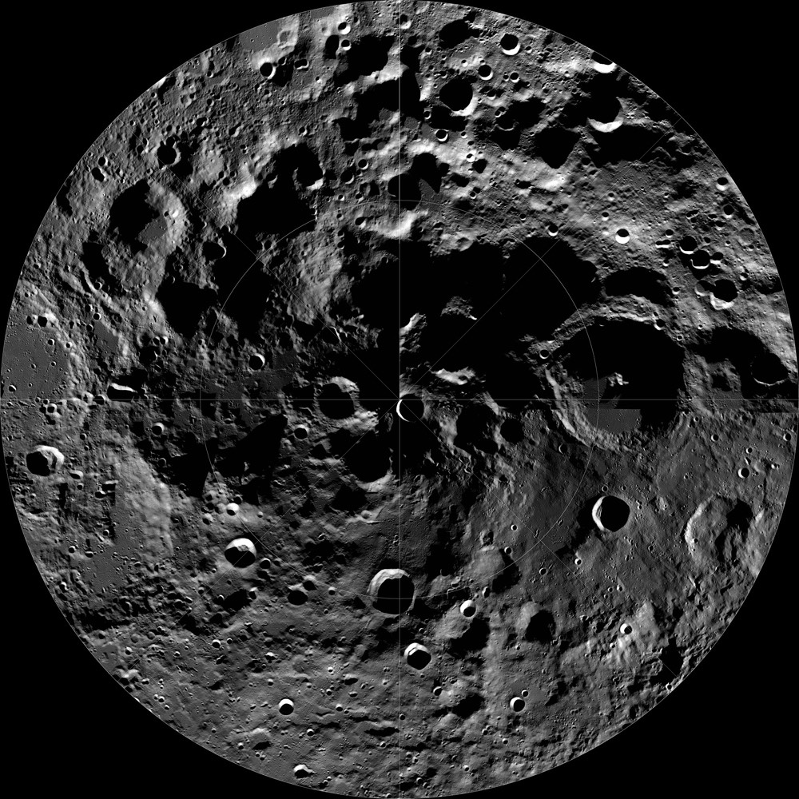

**The south polar region in real light** (LRO camera mosaic). The pure black patches are crater floors the Sun never reaches. NASA/GSFC/Arizona State University

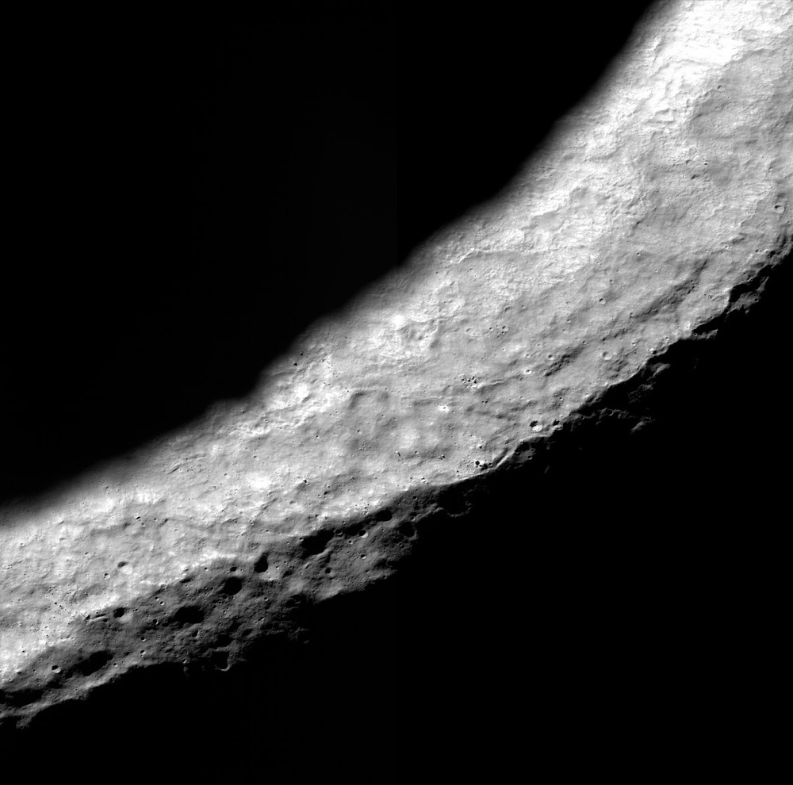

**Shackleton crater**, 21 km wide and 4 km deep, sits almost exactly on the pole. Its rim catches the grazing Sun; its floor has been dark for over two billion years. NASA/GSFC/ASU

## 3 · Name that feature

Swipe through the pictures, or use the arrows. Decide what you are looking at, pick a category if you like, then tap the picture to reveal.

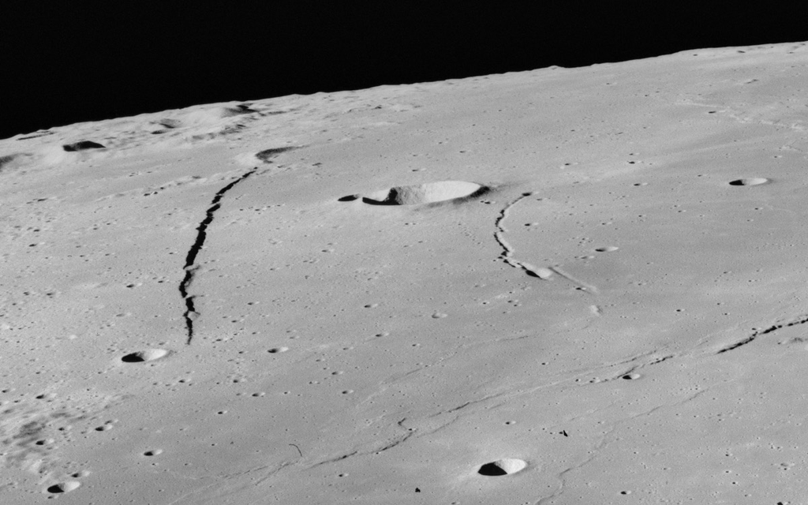

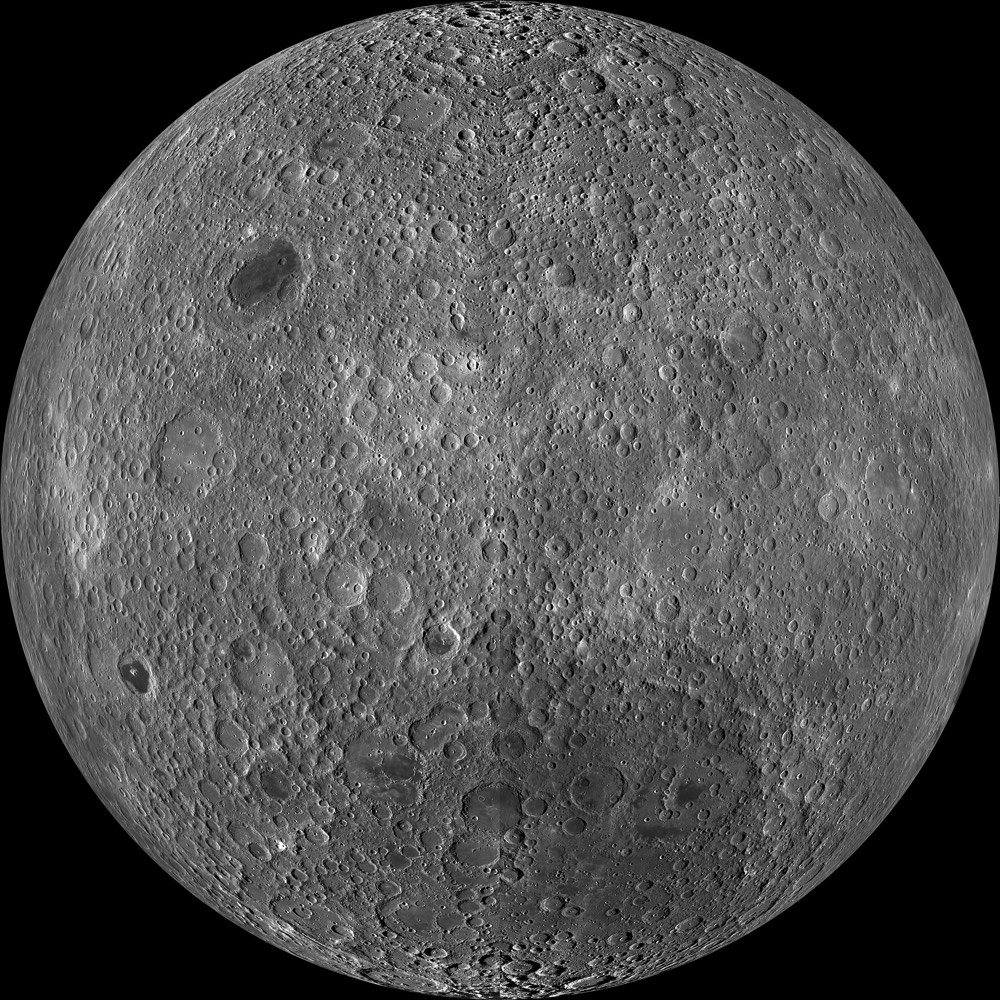

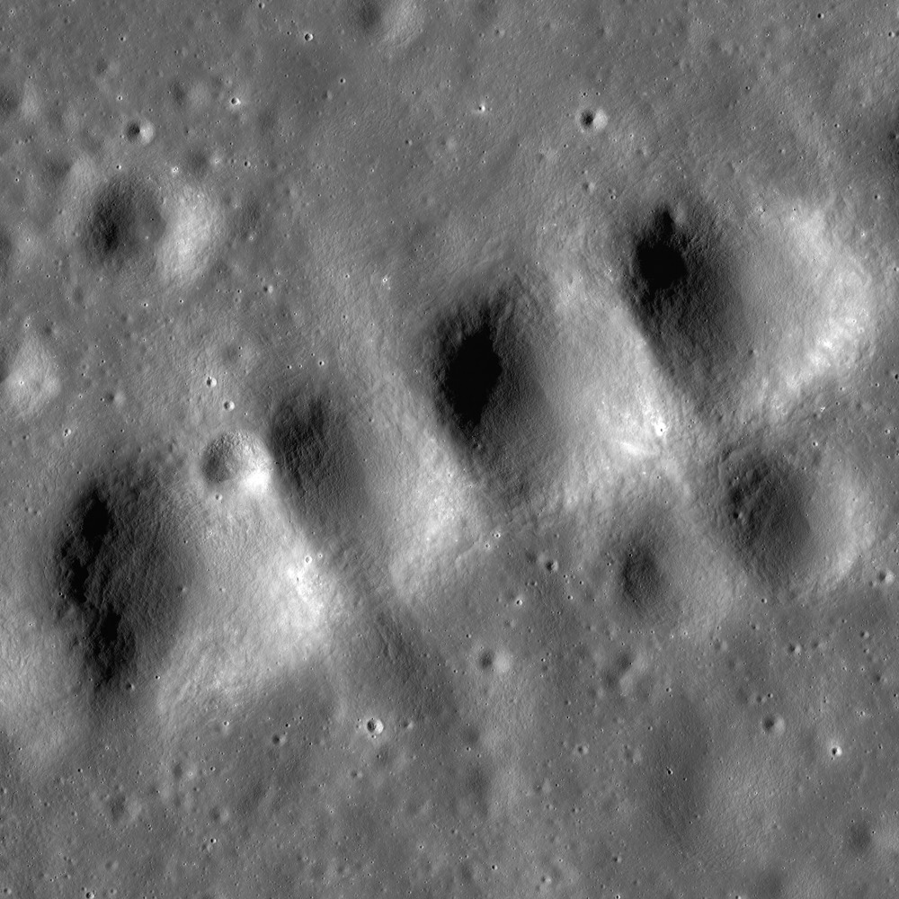

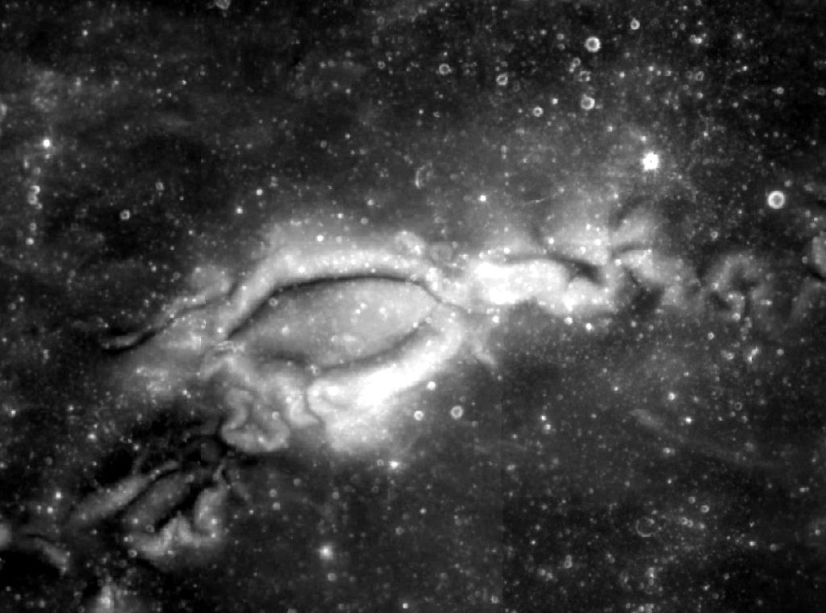

[figure not shown]

What is it?

Keyboard: ← → to move, space to reveal (click the picture first). On a phone, swipe left or right.

**Sources and further reading**

Want to dig deeper? Each title links straight to the original.

**Maps and names**

- [LROC QuickMap](https://quickmap.lroc.im-ldi.com/) (Lunar Reconnaissance Orbiter Camera team): zoom from the whole Moon down to boulders and Apollo landing sites.
- [Official names on the Moon](https://planetarynames.wr.usgs.gov/Page/MOON/target) (USGS / IAU): every named crater, mare and rille, with sizes and locations.
- [Lunar Reconnaissance Orbiter](https://science.nasa.gov/mission/lro/) (NASA): the spacecraft that took most of the pictures on this page, mapping the Moon since 2009.

**Maria and highlands**

- [What the Moon is made of](https://science.nasa.gov/moon/composition/) (NASA): why the maria are dark iron-rich lava and the highlands are bright.
- [Unified Geologic Map of the Moon](https://astrogeology.usgs.gov/search/map/unified_geologic_map_of_the_moon_1_5m_2020) (USGS): the whole Moon colored by rock type and age. Free to download. Fortezzo, Spudis & Harrel 2020, USGS

**Impact craters**

- [Tycho's central peak at sunrise](https://lroc.im-ldi.com/images/384) (LROC): a close, sideways look at the peak in the middle of Tycho, boulders and all.

**Rilles**

- [Rilles: sinuous, straight and arcuate](https://lroc.im-ldi.com/images/1147) (LROC): the three kinds of rille side by side, and how each one formed.
- [Apollo 15](https://www.nasa.gov/mission/apollo-15/) (NASA): the mission that landed beside Hadley Rille and drove to its edge.

**Lobate scarps**

- [A shrinking Moon may still be making moonquakes](https://www.nasa.gov/news-release/shrinking-moon-may-be-generating-moonquakes/) (NASA): how scarps show the Moon is cooling and shrinking.
- [Young faults found by LRO](https://doi.org/10.1126/science.1189590): the paper that first showed lobate scarps all over the Moon. Summary free; full paper behind a paywall. Watters et al. 2010, Science

**Regolith**

- [Apollo Moon rocks and soil](https://curator.jsc.nasa.gov/lunar/) (NASA Johnson Space Center): the 382 kg of samples Apollo brought home, and how scientists still study them.

**The poles**

- [Moon water and ices](https://science.nasa.gov/moon/moon-water-and-ices/) (NASA): why ice can survive in craters the Sun never reaches.
- [Ice seen at the surface near the poles](https://doi.org/10.1073/pnas.1802345115): the first direct evidence of exposed water ice in the shadowed craters. Free to read. Li et al. 2018, PNAS
- [Artemis](https://www.nasa.gov/humans-in-space/artemis/) (NASA): the program sending astronauts back to the Moon, aiming for the south pole.

The globes use LRO camera mosaics and LOLA laser heights (NASA/GSFC/Arizona State University; NASA Scientific Visualization Studio and Moon Trek); feature names and outlines follow the IAU/USGS Gazetteer.

**Image credits**

Photographs are NASA public-domain images: LRO WAC and NAC frames courtesy NASA/GSFC/Arizona State University (LROC); Apollo surface and orbital photographs from the Apollo archives (AS10-30-4450 processed by James Stuby, CC0; AS11-40-5878; AS15-85-11435; AS16-M-2486 processed by James Stuby; AS17-135-20649); Reiner Gamma from the Clementine mission. Textures for the globes are the LRO WAC mosaic and LOLA elevation and hillshade from NASA's Scientific Visualization Studio and Moon Trek, via the Moonmap build. Mare outlines from the Moonmap feature database (IAU/USGS nomenclature).